# Regression Assignment

Group 5

2024-07-17

```r
library(readr)
library(tidyverse)
library(ggplot2)
library(ggcorrplot)
library(dplyr)
library(summarytools)
library(olsrr)
library(AICcmodavg)
library(leaps)
library(corrplot)
library(MASS)
library(gridExtra)
library(knitr)
library(ggpubr)
library(flextable)
library(car)
library(tinytex)
```

# **Problem**

## **Scenario**

Nowadays, there has been a noticeable decline in people’s happiness levels, accompanied by a rise in mental health issues. This problem manifests in all aspects of our daily lives, such as work-related stress, social isolation, family responsibilities, and more. The decline in happiness not only affects individuals but also has repercussions for our community and society. If this trend continues to worsen, it will become a significant problem.

In recent years, we have observed a concerning trend: a decline in global happiness, which has captured our interest and motivated us to focus our research on happiness scores. According to Ipsos (2019), two-thirds of adults globally (64%) across 28 countries consider themselves happy. This prevalence of happiness is down 6 points from 70% in 2018. It is still 3 points higher than in March 2017 (61%) but 13 points below its December 2011 level of 77%.

The World Happiness Report (2024) highlights a decrease in happiness among those born after 1980. Additionally, a Gallup International survey at the end of 2021 showed a decline in global optimism and happiness compared to the previous year. This downward trend is linked to various factors, including economic instability, increasing inequality, and socio-political unrest. These findings suggest that happiness is a dynamic state, varying over time and across generations, influenced by numerous elements.

Given these considerations, we have chosen global happiness scores as the focus of our assignment and aim to identify the factors influencing these scores through regression analysis. Utilizing the 2019 happiness score data from Kaggle, we will conduct a comprehensive regression analysis to examine how various factors affect happiness.

## **Background**

Throughout history, the pursuit of happiness has remained a central focus in human societies. In recent years, the Happiness Index Score has gained prominence as a significant measure of well-being, attracting substantial attention as an indicator of a country’s overall prosperity and quality of life. The factors influencing happiness vary widely across countries and cultures. While universally sought, happiness can be defined differently by individuals. According to Cherry (2022), happiness encompasses a range of positive emotions such as fulfillment, joy, satisfaction, and contentment. Moreover, it signifies not just fleeting positivity but a state of well-being characterized by living a meaningful and deeply satisfying life. Achieving happiness, a crucial aspect of human existence, involves striking a balance between short-term pleasures and long-term goals (The Psychology Today Editorial Team, n.d.).

## **Problem Statement**

Given the noticeable decline in global happiness levels and the accompanying rise in mental health issues, it is crucial to identify the factors that most significantly influence happiness. This study aims to develop predictive models using various combinations of factors, including GDP per capita, social support, healthy life expectancy, freedom to make life choices, generosity, perceptions of corruption, and a categorical variable (Region_europe, where 0 represents non-European regions and 1 represents European regions). The objective is to determine the optimal combination of factors that best predict happiness scores and to develop the most effective model for determining happiness scores based on these factors. By leveraging regression analysis on the 2019 happiness score data from Kaggle, we seek to uncover actionable insights that can inform policies and initiatives aimed at reversing the decline in happiness and improving well-being worldwide. The ultimate goal is to use the best effective model developed to guide efforts in enhancing global happiness.

# **Data set**

## **Data description**

The dataset used for the analysis is the 2019 Happiness Index dataset, sourced from Kaggle. It includes various variables that measure and influence happiness across different countries. The specific variables used in the analysis are:

### Independent Variables

1. **GDP per capita (GDP)** - Represents the economic well-being of a country’s residents.
2. **Social support (SS)** - Measures the extent to which individuals have access to support from family, friends, and other social networks.
3. **Healthy life expectancy (HLE**) - Indicates the length of time individuals can expect to live in good health.
4. **Freedom to make life choices (FTMLC)** - Represents the level of autonomy and control individuals have over their lives.
5. **Generosity (GEN)** - Reflects the quality of being kind and giving.
6. **Perception of corruption (POC)** - Shows the extent to which corruption is perceived to be prevalent in a society.
7. **Region_europe (Europe):** Divides the countries into two categories: European Region (1) and Non-European Region (0). Region_europe is also a **categorical variable**.

### Dependent Variable

- **Happiness Score (Score)** - A measure used in the field of happiness studies to quantify the level of happiness or well-being of individuals or groups.

## **Data source**

The dataset is sourced from Kaggle and can be accessed using the following link: [2019 Happiness Index Dataset](https://www.kaggle.com/datasets/sougatapramanick/happiness-index-2018-2019?select=2019.csv)

# **Descriptive statistics**

## **Summary**

```r
data_2019 <- read.csv("D:/Backup_20231111/c/documents/Sunway Degree Y3/SEM 2/MAT 3024 Regression Analysis/Assignment/Data/2019.csv", header = TRUE)

glimpse(data_2019)
```

```
## Rows: 156
## Columns: 10
## $ Overall.rank                 <int> 1, 2, 3, 4, 5, 6, 7, 8, 9, 10, 11, 12, 13…
## $ Country.or.region            <chr> "Finland", "Denmark", "Norway", "Iceland"…
## $ Region_europe                <int> 1, 1, 1, 1, 1, 1, 1, 0, 0, 1, 0, 0, 0, 1,…
## $ Score                        <dbl> 7.769, 7.600, 7.554, 7.494, 7.488, 7.480,…
## $ GDP.per.capita               <dbl> 1.340, 1.383, 1.488, 1.380, 1.396, 1.452,…
## $ Social.support               <dbl> 1.587, 1.573, 1.582, 1.624, 1.522, 1.526,…
## $ Healthy.life.expectancy      <dbl> 0.986, 0.996, 1.028, 1.026, 0.999, 1.052,…
## $ Freedom.to.make.life.choices <dbl> 0.596, 0.592, 0.603, 0.591, 0.557, 0.572,…
## $ Generosity                   <dbl> 0.153, 0.252, 0.271, 0.354, 0.322, 0.263,…
## $ Perceptions.of.corruption    <dbl> 0.393, 0.410, 0.341, 0.118, 0.298, 0.343,…
```

```r
selected_data <- subset(data_2019, select = -c(Overall.rank, Country.or.region))
colnames(selected_data) <- c("Europe","Score","GDP","SS","HLE","FTMLC","Gen","POC")

descr(selected_data)
```

```
## Descriptive Statistics
## selected_data
## N: 156
##
##                     Europe    FTMLC      GDP      Gen      HLE      POC    Score       SS
## ----------------- -------- -------- -------- -------- -------- -------- -------- --------
##              Mean     0.26     0.39     0.91     0.18     0.73     0.11     5.41     1.21
##           Std.Dev     0.44     0.14     0.40     0.10     0.24     0.09     1.11     0.30
##               Min     0.00     0.00     0.00     0.00     0.00     0.00     2.85     0.00
##                Q1     0.00     0.31     0.59     0.11     0.54     0.05     4.54     1.06
##            Median     0.00     0.42     0.96     0.18     0.79     0.09     5.38     1.27
##                Q3     1.00     0.51     1.23     0.25     0.88     0.14     6.19     1.45
##               Max     1.00     0.63     1.68     0.57     1.14     0.45     7.77     1.62
##               MAD     0.00     0.15     0.45     0.10     0.26     0.07     1.21     0.28
##               IQR     1.00     0.20     0.63     0.14     0.33     0.09     1.64     0.40
##                CV     1.71     0.37     0.44     0.52     0.33     0.85     0.21     0.25
##          Skewness     1.11    -0.67    -0.38     0.73    -0.60     1.62     0.01    -1.11
##       SE.Skewness     0.19     0.19     0.19     0.19     0.19     0.19     0.19     0.19
##          Kurtosis    -0.78    -0.14    -0.81     1.05    -0.37     2.23    -0.66     1.10
##           N.Valid   156.00   156.00   156.00   156.00   156.00   156.00   156.00   156.00
##         Pct.Valid   100.00   100.00   100.00   100.00   100.00   100.00   100.00   100.00
```

## **Plot**

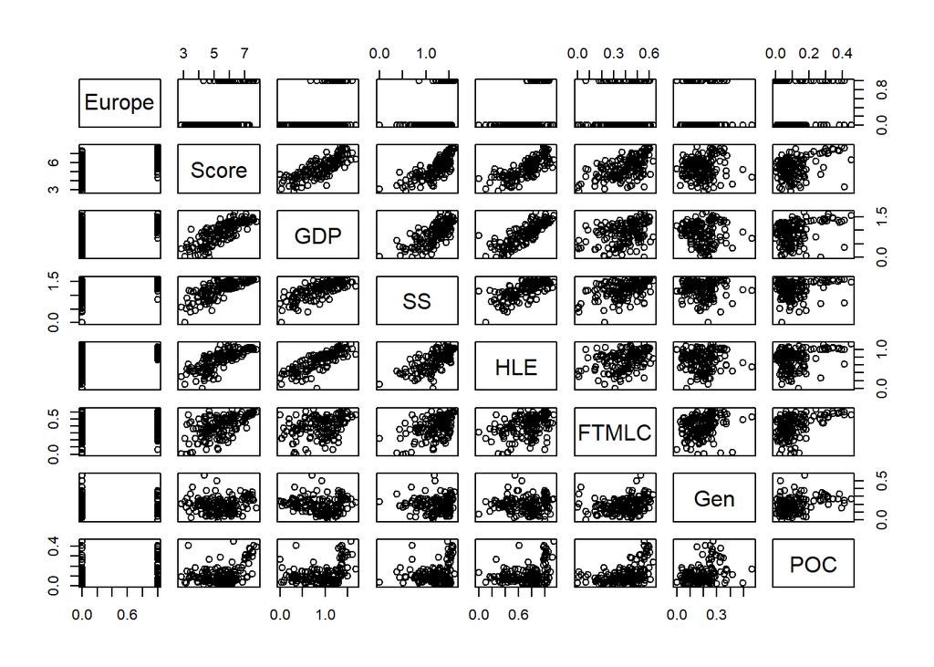

```r
plot(selected_data)
```

# **(ii) Data Visualization**

## **Scatterplots**

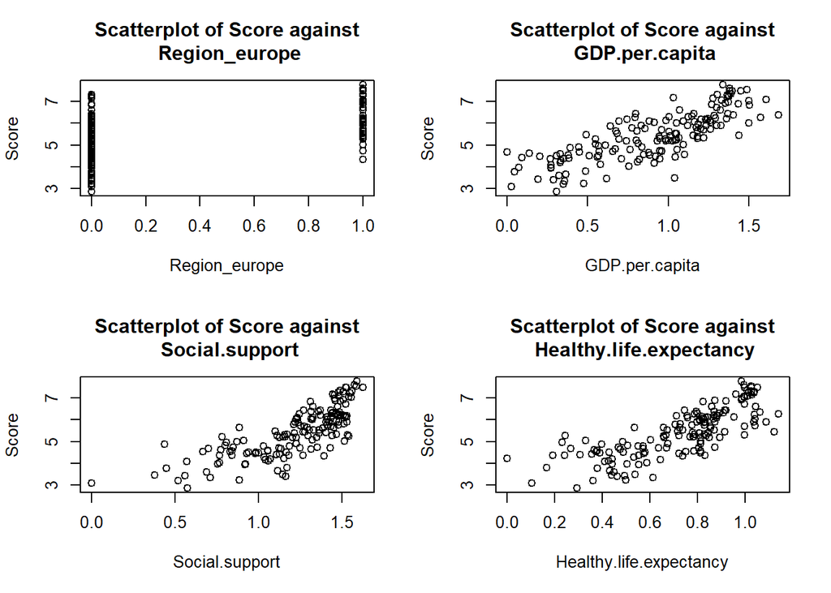

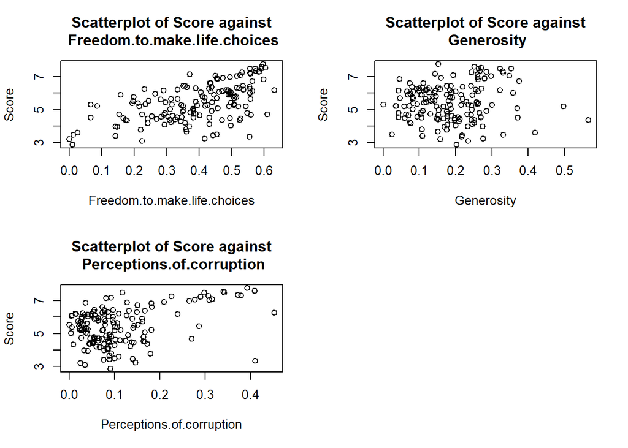

```r
y_var <- data_2019$Score
x_vars <- subset(data_2019, select = -c(Score, Overall.rank, Country.or.region))
x_var_names <- names(x_vars)

par(mfrow = c(2,2))

# Create scatter plots
for(i in seq_along(x_vars)){
  x_var <- x_vars[[i]]
  plot(x = x_var, y = y_var, main = paste("Scatterplot of Score against\n", x_var_names[i]),
       xlab = x_var_names[i], ylab = "Score")
}
```

# **(iii) Regression Models**

## **Correlation between y and x**

```r
# Compute correlations
correlations <- sapply(x_vars, function(x_var) cor(x_var, y_var))

correlation_df <- data.frame("X_Variables" = names(correlations), "Correlations between Y and X" = correlations, row.names = NULL)

correlation_df %>%
  regulartable() %>%
  bold(part = "header") %>%
  width(j = 1, width = 3) %>%
  width(j = 2, width = 2)
```

| X_Variables | Correlations.between.Y.and.X |
| --- | --- |
| Region_europe | 0.45811519 |
| GDP.per.capita | 0.79388287 |
| Social.support | 0.77705779 |
| Healthy.life.expectancy | 0.77988315 |
| Freedom.to.make.life.choices | 0.56674183 |
| Generosity | 0.07582369 |
| Perceptions.of.corruption | 0.38561307 |

**Conclusion:**

Since the correlation coefficient, $r$ of GDP per capita is the highest among the other factors, this indicates that *GDP per capita* is the **most influential variable**.

## **Correlation Matrix**

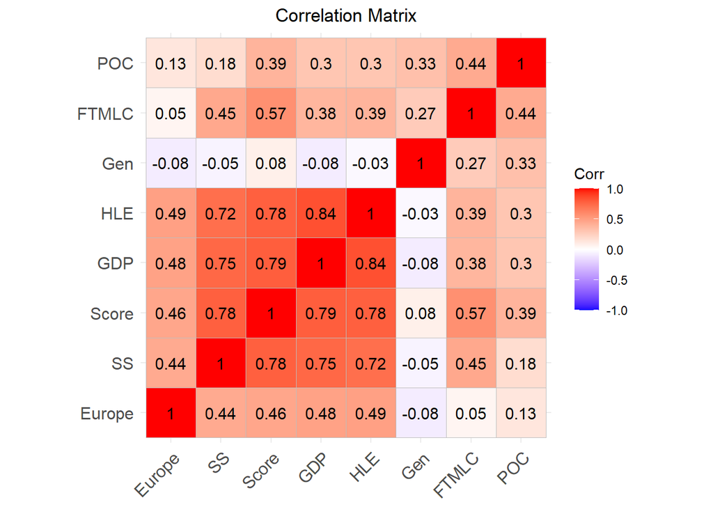

```r
corr_matrix <- cor(selected_data)

ggcorrplot(corr_matrix, hc.order = TRUE, lab = TRUE, title = "Correlation Matrix") +
  theme(plot.title = element_text(hjust = 0.5))
```

1. **Strong Correlations**
   - Social Support, GDP per capita, and Healthy Life Expectancy have the strongest correlations with happiness scores among other factors, with correlation coefficients of 0.78, 0.79, and 0.78, respectively.
2. **Moderate to Weak Correlations**
   - Freedom to make life choices, European region, and Perceptions of Corruption show moderate to weak correlations with happiness scores with coefficient values of 0.57, 0.46 and 0.39 respectively.
3. **Neutral Relationship**
   - Generosity exhibits a neutral relationship with happiness scores, indicating it does not strongly influence them.
4. **Correlation Matrix**
   - In the correlation matrix, lighter colors represent weaker relationships. Generosity has correlation coefficients close to 0 with most variables, suggesting it may not be a critical factor in determining the happiness index compared to other more influential variables.

## **Simple Linear Regression**

### Model 1: Score (y) against GDP per capita (x)

#### Summary

```r
colnames(data_2019) <- c("Rank","CoR","Europe","Score","GDP","SS","HLE","FTMLC","Gen","POC")
SLR <- lm(Score ~ GDP, data = data_2019)
summary(SLR)
```

```
##
## Call:
## lm(formula = Score ~ GDP, data = data_2019)
##
## Residuals:
##      Min       1Q   Median       3Q      Max
## -2.22044 -0.48361  0.00828  0.48433  1.47409
##
## Coefficients:
##             Estimate Std. Error t value Pr(>|t|)
## (Intercept)   3.3993     0.1353   25.12   <2e-16 ***
## GDP           2.2181     0.1369   16.20   <2e-16 ***
## ---
## Signif. codes:  0 '***' 0.001 '**' 0.01 '*' 0.05 '.' 0.1 ' ' 1
##
## Residual standard error: 0.679 on 154 degrees of freedom
## Multiple R-squared:  0.6303, Adjusted R-squared:  0.6278
## F-statistic: 262.5 on 1 and 154 DF,  p-value: < 2.2e-16
```

**Least square regression line equation:**

$\hat{y}$ = 3.3993 + 2.2181$x$

**Interpretation for estimated coefficients:**

**Intercept,** $\beta_0$: On average, the model predicts $score$ to be 3.3993 when the $GDP.per.capita$ is 0.

**Slope,** $\beta_1$: On average, the model predicts $Score$ to be increase by 2.2181, for every 1 unit increase in $GDP.per.capita$.

**Interpretation for Coefficient of determination**

**R-squared:** 63.03% of the variation in $Score$ can be explained by variation in $GDP.per.capita$.

#### Scatterplot

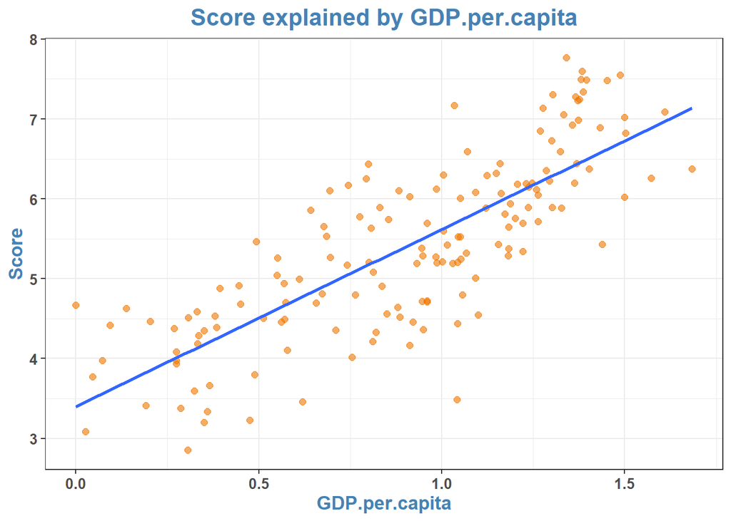

```r
data_2019 %>%
  ggplot(aes(x = GDP, y = Score))+
  geom_point(size = 2,
             color = "darkorange2",
             alpha = .6)+
  geom_smooth(method = lm, se = F)+
  theme_bw()+
  labs(title = "Score explained by GDP.per.capita",
       x = "GDP.per.capita",
       Y = "Score")+
  theme(plot.title =
          element_text(size = 16,
                       face = "bold",
                       color = "steelblue",
                       hjust = 0.5),
        axis.text =
          element_text(size = 10,
                       face = "bold"),
        axis.title =
          element_text(size = 13,
                       color = "steelblue",
                       face = "bold"))
```

The scatter plot shows a positive linear relationship between GDP per capita and the score. This means that as GDP per capita increases, the score also tends to increase.

#### Significant Test

Determine at 1% significance level for testing $\beta_1$.

$Ho:\beta_1=0$ vs $H1:\beta_1\neq0$

Decision rule: Reject $H_o$ if $p-value < \alpha$

**Decision***:* Since $p-value < \alpha$, **reject** $H_o$ .

Conclusion: There is a linear relationship between $Score$ and $GDP.per.capita$.

#### Confidence Interval

```r
confint(SLR)
```

```
##                2.5 %   97.5 %
## (Intercept) 3.132016 3.666675
## GDP         1.947689 2.488607
```

95% confidence interval is [1.95, 2.49]. We are 95% confident that the true $\beta_1$ is between 1.95 and 2.49.

#### Prediction Modelling

```r
new_df1 <- data.frame(GDP = c(1.25, 1.58, 1.03))
predict(SLR, new_df1)
```

```
##        1        2        3
## 6.172030 6.904019 5.684038
```

Using the code above we can show that this SLR model predicts the score for happiness of a country will be 6.17203, 6.904019 and 5.684038 if the GDP.per.capita is 1.25, 1.58 and 1.03 respectively.

#### CI on mean response

```r
predict(SLR, new_df1,
        interval = "confidence",
        level = 0.99)
```

```
##        fit      lwr      upr
## 1 6.172030 5.984229 6.359832
## 2 6.904019 6.624423 7.183615
## 3 5.684038 5.535397 5.832678
```

- For **group 1**, the estimated mean response (`fit`) is 6.172030. The lower bound (`lwr`) of the 99% confidence interval is 5.984229, and the upper bound (`upr`) is 6.359832. This means we are 99% confident that the true mean response for group 1 lies between 5.984229 and 6.359832.
- For **group 2**, the estimated mean response is 6.904019, with a 99% confidence interval ranging from 6.624423 to 7.183615.
- For **group 3**, the estimated mean response is 5.684038, with a 99% confidence interval ranging from 5.535397 to 5.832678.

#### PI for future observation

```r
predict(SLR, new_df1,
        interval = "prediction",
        level = 0.99)
```

```
##        fit      lwr      upr
## 1 6.172030 4.391051 7.953010
## 2 6.904019 5.111035 8.697003
## 3 5.684038 3.906761 7.461314
```

- For **group 1**, the estimated mean response (`fit`) is 6.172030. The lower bound (`lwr`) of the 99% prediction interval is 4.391051, and the upper bound (`upr`) is 7.953010. This means we are 99% confident that the true value of a future observation for group 1 lies between 4.391051 and 7.953010.
- For **group 2**, the estimated mean response is 6.904019, with a 99% prediction interval ranging from 5.111035 to 8.697003.
- For **group 3**, the estimated mean response is 5.684038, with a 99% prediction interval ranging from 3.906761 to 7.461314.

#### ANOVA

```r
anova(SLR)
```

```
## Analysis of Variance Table
##
## Response: Score
##            Df  Sum Sq Mean Sq F value    Pr(>F)
## GDP         1 121.040 121.040   262.5 < 2.2e-16 ***
## Residuals 154  71.011   0.461
## ---
## Signif. codes:  0 '***' 0.001 '**' 0.01 '*' 0.05 '.' 0.1 ' ' 1
```

- **F value:** 262.5, indicating a strong relationship.
- **p-value:** Less than 2.2e-16, suggesting that GDP significantly affects Score.
- GDP is statistically significant at 0.001 significant level.

In conclusion, this ANOVA table shows that the GDP variable has a statistically significant impact on the Score, as indicated by the very small p-value and the high F value.

#### Residual Analysis

##### Scatterplot

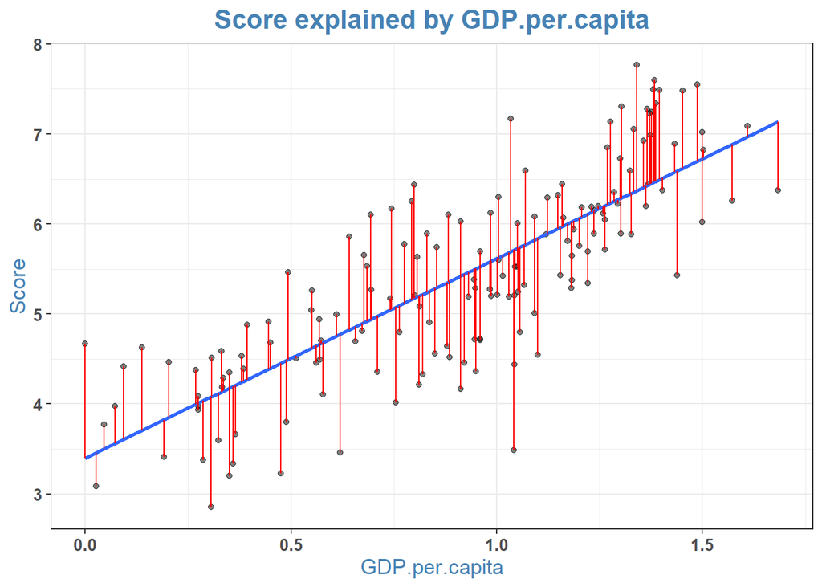

```r
data_2019 %>%
  mutate(predicted = predict(lm(Score ~ GDP, data = data_2019))) %>%
  ggplot(aes(x = GDP, y = Score))+
  geom_point(size = 1.5, alpha = .5)+
  geom_smooth(method = lm, se = F)+
  geom_segment(aes(xend = GDP, yend = predicted), color = "red")+
  theme_bw()+
  labs(title = "Score explained by GDP.per.capita",
       x = "GDP.per.capita",
       Y = "Score")+
  theme(plot.title =
          element_text(size = 16,
                       face = "bold",
                       color = "steelblue",
                       hjust = 0.5),
        axis.text =
          element_text(size = 10,
                       face = "bold"),
        axis.title =
          element_text(size = 13,
                       color = "steelblue",))
```

- **Positive Relationship:** The regression line’s upward slope indicates that higher GDP per capita is associated with higher Scores, suggesting that greater economic output per person tends to correspond with higher well-being or happiness scores.
- **Spread of Residuals:** Residual lengths vary, showing that the regression model does not perfectly predict the Scores. Some points are close to the regression line (small residuals), while others are further away (large residuals).
- **Heteroscedasticity:** Residual spread increases with GDP per capita, suggesting potential heteroscedasticity. This indicates that the variability in Scores may be larger for countries with higher GDP per capita, affecting the reliability of the regression estimates.
- **Outliers:** Some data points, especially at higher GDP per capita levels, are far from the regression line, indicating potential outliers that might significantly impact the regression model.

##### Summary

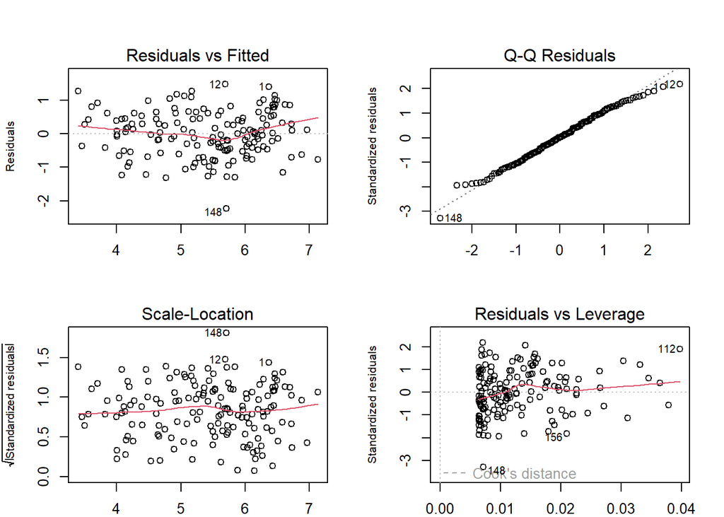

```r
par(mfrow = c(2,2),mar =c(2,4,4,2), cex.lab = 0.8)
plot(SLR)
```

##### Histogram of residuals

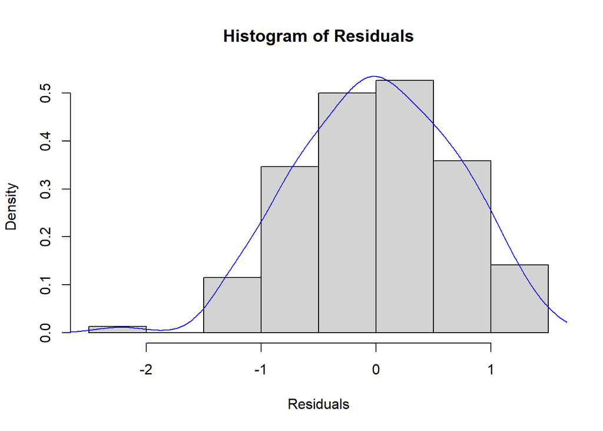

```r
hist(residuals(SLR), main = "Histogram of Residuals", xlab = "Residuals", freq = FALSE)
lines(density(residuals(SLR)), col = "blue")
```

The residuals follow a normal distribution.

## **Multiple Linear Regression**

### **Model 1 : Initial full model**

#### Summary

```r
full_model <- lm(Score
                 ~ GDP
                 + Europe
                 + SS
                 + HLE
                 + FTMLC
                 + Gen
                 + POC,
                 data = data_2019)

summary(full_model)
```

```
##
## Call:
## lm(formula = Score ~ GDP + Europe + SS + HLE + FTMLC + Gen +
##     POC, data = data_2019)
##
## Residuals:
##      Min       1Q   Median       3Q      Max
## -1.72757 -0.34730  0.00141  0.37720  1.14263
##
## Coefficients:
##             Estimate Std. Error t value Pr(>|t|)
## (Intercept)   1.8805     0.2142   8.777 3.77e-15 ***
## GDP           0.7405     0.2172   3.409  0.00084 ***
## Europe        0.2172     0.1162   1.868  0.06368 .
## SS            1.0537     0.2380   4.428 1.83e-05 ***
## HLE           0.9673     0.3370   2.870  0.00471 **
## FTMLC         1.6152     0.3820   4.228 4.11e-05 ***
## Gen           0.4967     0.4936   1.006  0.31601
## POC           0.8993     0.5393   1.668  0.09752 .
## ---
## Signif. codes:  0 '***' 0.001 '**' 0.01 '*' 0.05 '.' 0.1 ' ' 1
##
## Residual standard error: 0.5291 on 148 degrees of freedom
## Multiple R-squared:  0.7843, Adjusted R-squared:  0.774
## F-statistic: 76.86 on 7 and 148 DF,  p-value: < 2.2e-16
```

```r
sort(summary(full_model)$coefficients[, "t value"])
```

```
##         Gen         POC      Europe         HLE         GDP       FTMLC
##    1.006095    1.667563    1.868426    2.869960    3.409135    4.228227
##          SS (Intercept)
##    4.428307    8.777170
```

The t-value measures the strength of the relationship between each predictor variable and the response variable (score in this dataset). A higher t-value indicates a stronger impact on the response variable. In this dataset, sorting the t-values in ascending order shows that Generosity has the lowest t-value, suggesting it has the least impact on scores. Conversely, Social Support has the highest t-value (excluding the intercept), indicating it has the most significant impact on scores.

#### Scatterplot

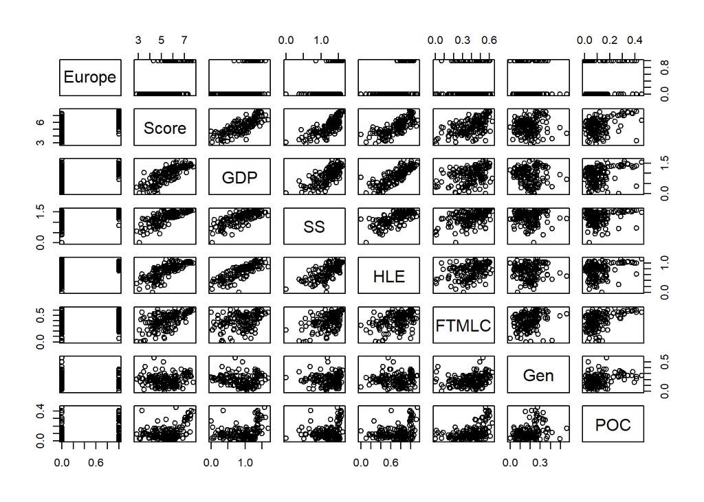

```r
plot(subset(data_2019, select = -c(Rank, CoR)))
```

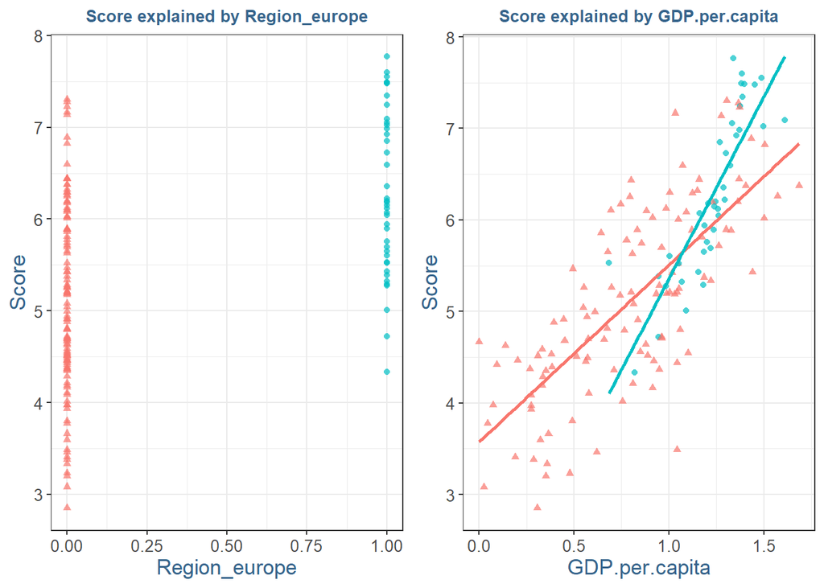

```r
plot_list <- list()

for(i in seq_along(x_vars)){
  x_var <- x_vars[[i]]
  p <- data_2019 %>%
    ggplot(aes_string(x = x_var, y = "Score", color = "as.factor(Europe)", shape = "as.factor(Europe)")) +
    geom_point(alpha = 0.7) +
    scale_shape_manual(values=c(17, 16)) +
    geom_smooth(method = "lm", se = F) +
    theme_bw() +
    labs(title = paste("Score explained by", x_var_names[i]),
         x = x_var_names[i],
         y = "Score")+
    theme(plot.title =
          element_text(size = 10,
                       face = "bold",
                       color = "steelblue4",
                       hjust = 0.5),
        axis.text =
          element_text(size = 10),
        axis.title =
          element_text(size = 13,
                       color = "steelblue4"))

    if(i != 7){
        p <- p + theme(legend.position = "NONE")
    } else {
        p <- p + labs(color = "Region (0 = Non-Europe, 1 = Europe)", shape = "Region (0 = Non-Europe, 1 = Europe)") +
                  guides(color = guide_legend(override.aes = list(size = 3.4))) +
                  theme(legend.key.size = unit(1.4, "cm"))

    }

    plot_list[[i]] <- p
}

combined_plot1 <- ggarrange(plot_list[[1]], plot_list[[2]], ncol = 2, nrow = 1)
combined_plot2 <- ggarrange(plot_list[[3]], plot_list[[4]], ncol = 2, nrow = 1)
combined_plot3 <- ggarrange(plot_list[[5]], plot_list[[6]], ncol = 2, nrow = 1)

combined_plot1
```

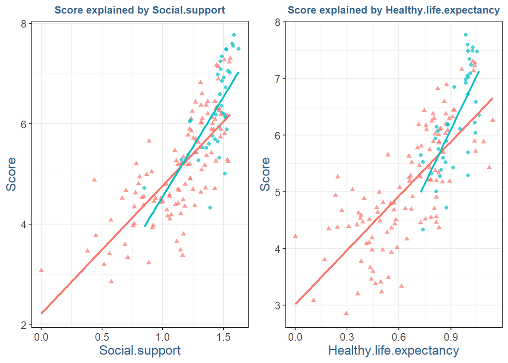

```r
combined_plot2
```

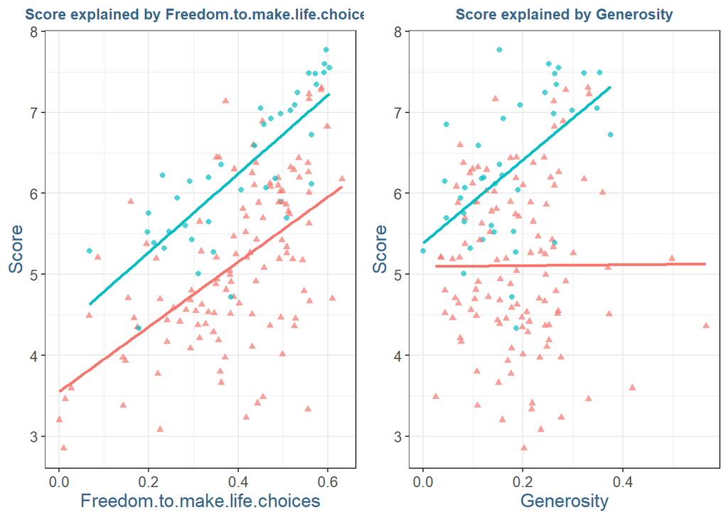

```r
combined_plot3
```

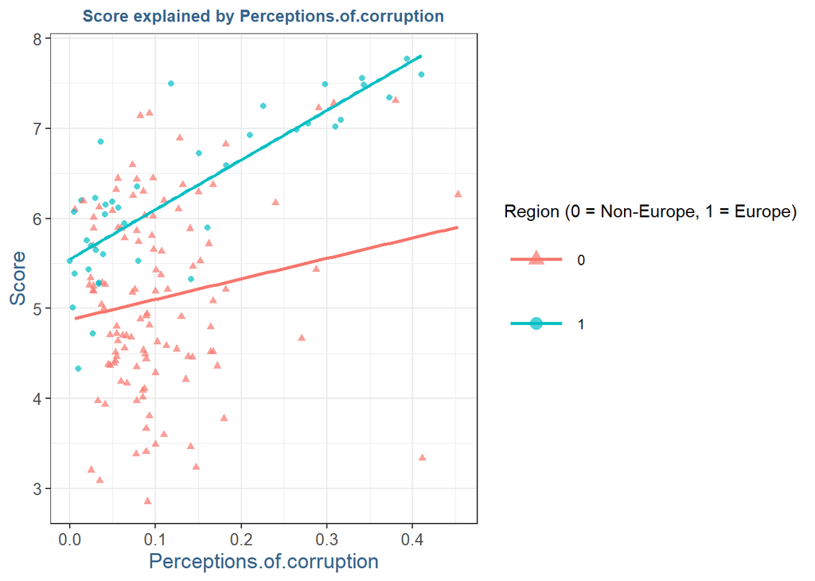

```r
plot_list[7]
```

There is a positive correlation between all the regressor variables and the response variable, score. In all the plots, European regions (represented in blue) generally show stronger and more positive relationships between the independent variables and the scores compared to non-European regions.

#### Confidence Interval

```r
confint(full_model)
```

```
##                  2.5 %    97.5 %
## (Intercept)  1.4570959 2.3038478
## GDP          0.3112858 1.1698113
## Europe      -0.0125168 0.4468265
## SS           0.5835025 1.5239474
## HLE          0.3012586 1.6333217
## FTMLC        0.8603232 2.3701148
## Gen         -0.4788538 1.4721717
## POC         -0.1664057 1.9650357
```

- The 95% confidence intervals for the coefficients of Intercept and GDP per Capita are (1.46, 2.30) and (0.31, 1.17), respectively, indicating that we are 95% confident that the true values of these coefficients fall within these ranges.
- The confidence interval for the European region includes zero, suggesting that its effect on the score might not be statistically significant.
- The positive confidence intervals for both healthy life expectancy and freedom to make life choices exclude zero, suggesting they have a positive effect on the score.
- The confidence intervals for generosity and perceptions of corruption range from negative to positive values, indicating uncertainty about their effects on the score.
- Narrow confidence intervals indicate more precise estimates, and intervals that exclude zero are usually considered statistically significant at the 95% confidence level, implying a non-zero effect of the variable on the score.

#### Significance test

Since the confidence interval for the Europe, Generosity and Perception of Corruption includes zero, suggesting that its effect on the score might not be statistically significant, we will carry out a t-test to reassess the significance of including these variables in our model.

##### t-test on Europe

Let $\beta_2 = \text{Europe}$.

Determine at 5% significance level for testing $β_2$ (Europe).

$H_o:β_2=0 \quad vs \quad H_1:β_2\neq0$

Decision rule: Reject $H_o$ if $\mid t_0 \mid > t_{\frac{\alpha}{2}, \enspace n-k-1}$

From the summary, $t_0 = 1.868$

From the t-distribution table, $t_{0.025, 149} = 1.9760$

Decision: Since $t_0 < 1.9760$ , we do not reject $H_0$.

Conclusion: This indicates that $\beta_2$ does not contribute significantly to the model given the other regressors is in the model at 5% level of significance.

##### t-test on Generosity

Let $\beta_6 = \text{Generosity}$.

Determine at 5% significance level for testing $β_6$ (Generosity).

$H_o:β_6=0 \quad vs \quad H_1:β_6\neq0$

Decision rule: Reject $H_o$ if $\mid t_0 \mid > t_{\frac{\alpha}{2}, \enspace n-k-1}$

From the summary, $t_0 = 1.006$

From the t-distribution table, $t_{0.025, 149} = 1.9760$

Decision: Since $t_0 < 1.9760$ , we do not reject $H_0$.

Conclusion: This indicates that $\beta_6$ does not contribute significantly to the model given the other regressors is in the model at 5% level of significance.

##### t-test on Perceptions of Corruptions

Let $\beta_6 = \text{ Perceptions of Corruptions}$.

Determine at 5% significance level for testing $β_7$ (Perceptions of Corruptions).

$H_o:β_7=0 \quad vs \quad H_1:β_7\neq0$

Decision rule: Reject $H_o$ if $\mid t_0 \mid > t_{\frac{\alpha}{2}, \enspace n-k-1}$

From the summary, $t_0 = 1.668$

From the t-distribution table, $t_{0.025, 149} = 1.9760$

Decision: Since $t_0 < 1.9760$ , we do not reject $H_0$.

Conclusion: This indicates that $\beta_7$ does not contribute significantly to the model given the other regressors is in the model at 5% level of significance.

#### Prediction Modelling

```r
new_df2 <- data.frame(
  Europe = c(1, 0, 1),
  GDP = c(0.893, 1.904, 1.276),
  SS = c(0.475, 0.892, 1.369),
  HLE = c(0.984, 1.043, 0.749),
  FTMLC = c(0.428, 0.583, 0.379),
  Gen = c(0.173, 0.376, 0.206),
  POC = c(0.378, 0.025, 0.257)
)

predict(full_model, new_df2)
```

```
##        1        2        3
## 5.328446 6.390182 6.155220
```

- **Observation 1:** Given the input features for the first observation, the model predicts a score of approximately 5.328.
- **Observation 2:** For the second observation, with its set of predictor values, the predicted score is approximately 6.390.
- **Observation 3:** The third observation, based on its predictors, is predicted to have a score of approximately 6.155.

#### CI on mean response

```r
predict(full_model, new_df2,
        interval = "confidence",
        level=0.95)
```

```
##        fit      lwr      upr
## 1 5.328446 4.826180 5.830712
## 2 6.390182 5.810782 6.969582
## 3 6.155220 5.905424 6.405016
```

- For **group 1**, the estimated mean response (`fit`) is 5.328446. The lower bound (`lwr`) of the 95% confidence interval is 4.826180, and the upper bound (`upr`) is 5.830712. This means we are 95% confident that the true mean response for group 1 lies between 4.826180 and 5.830712.
- For **group 2**, the estimated mean response is 6.390182, with a 95% confidence interval ranging from 5.810782 to 6.969582.
- For **group 3**, the estimated mean response is 6.155220, with a 95% confidence interval ranging from 5.905424 to 6.405016.

#### PI for future observation

```r
predict(full_model, new_df2,
        interval = "prediction",
        level=0.95)
```

```
##        fit      lwr      upr
## 1 5.328446 4.168472 6.488420
## 2 6.390182 5.194786 7.585578
## 3 6.155220 5.080201 7.230239
```

- For **group 1**, the estimated mean response (`fit`) is 5.328446. The lower bound (`lwr`) of the 95% prediction interval is 4.168472, and the upper bound (`upr`) is 6.488420. This means we are 95% confident that the true value of a future observation for group 1 lies between 4.168472 and 6.488420.
- For **group 2**, the estimated mean response is 6.390182, with a 95% prediction interval ranging from 5.194786 to 7.585578.
- For **group 3**, the estimated mean response is 6.155220, with a 95% prediction interval ranging from 5.080201 to 7.230239.

#### ANOVA

```r
anova(full_model)
```

```
## Analysis of Variance Table
##
## Response: Score
##            Df  Sum Sq Mean Sq  F value    Pr(>F)
## GDP         1 121.040 121.040 432.3441 < 2.2e-16 ***
## Europe      1   1.495   1.495   5.3412 0.0222076 *
## SS          1  13.131  13.131  46.9020 1.861e-10 ***
## HLE         1   3.979   3.979  14.2124 0.0002354 ***
## FTMLC       1   9.549   9.549  34.1067 3.186e-08 ***
## Gen         1   0.644   0.644   2.3010 0.1314207
## POC         1   0.779   0.779   2.7808 0.0975171 .
## Residuals 148  41.434   0.280
## ---
## Signif. codes:  0 '***' 0.001 '**' 0.01 '*' 0.05 '.' 0.1 ' ' 1
```

```r
sort(anova(full_model)$"F value")
```

```
## [1]   2.301037   2.780767   5.341215  14.212410  34.106668  46.902027 432.344055
```

The F-statistic tests the null hypothesis that all the coefficients except for intercept are 0 with an alternative of at least one is not. With higher values of F, a stronger relationship between the variable and score is implied.

By sorting the F-values:

- GDP per Capita has the highest F-value at 432.344, indicating the strongest relationship with the score.
- This is followed by Social Support, Freedom to Make Life Choices, Healthy Life Expectancy, European Region, and Perception of Corruption.
- Generosity has the lowest F-value at 2.301, indicating the weakest relationship with the score.

#### Residuals Analysis

##### Summary

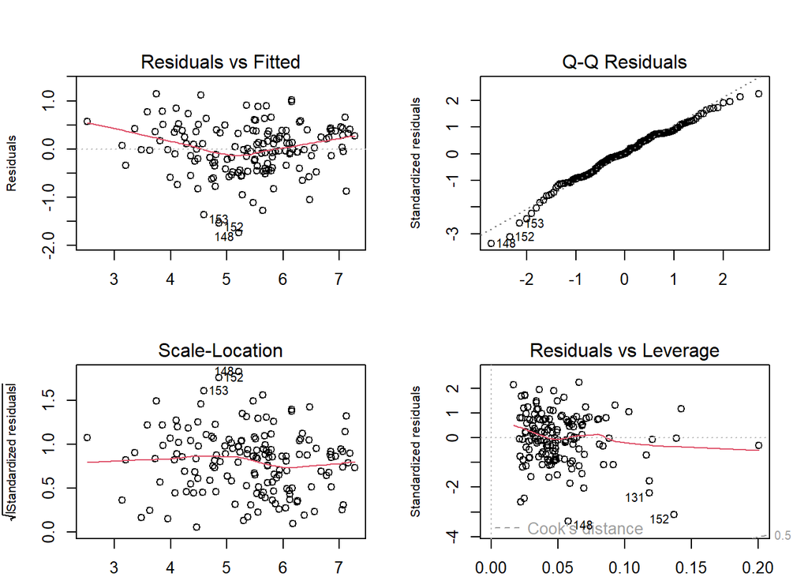

```r
par(mfrow = c(2,2),mar =c(2,4,4,2), cex.lab = 0.8)
plot(full_model)
```

##### Standardized Residuals

```r
sta_res_full <- rstandard(full_model)
dfstares_full <- data.frame(sta_res_full)
dfstares_full$x <- seq(1:nrow(data_2019))

fittedvalue <- fitted(full_model)
```

##### Studentized Residuals

```r
stu_res_full <- studres(full_model)
dfstures_full <- data.frame(stu_res_full)
dfstures_full$x <- seq(1:nrow(data_2019))
```

##### Histogram for standardized & studentized residuals

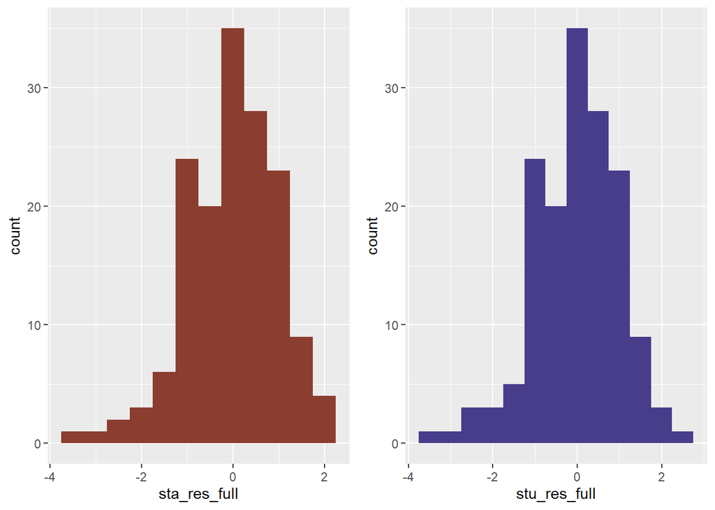

```r
sta_hist <- ggplot(dfstares_full, aes(x = sta_res_full)) + geom_histogram(binwidth = 0.5, fill = "coral4")

stu_hist <- ggplot(dfstures_full, aes(x = stu_res_full)) + geom_histogram(binwidth = 0.5,fill = "darkslateblue")

ggarrange(sta_hist, stu_hist, ncol = 2, nrow = 1)
```

- Both the Standardized Residuals and Studentized Residuals Histogram are bell-shaped but slightly skewed to the left. This implies most of the residuals are in positive values but there might be some outliers that negatively impact the residuals.
- Both counts of the histograms also reached the peak at 0 residual, which is typical when the model fits the data well. Since the residuals are mostly centered around zero and follow a bell-shaped curve, it suggests that the residuals are approximately normally distributed and are generally good for linear regression assumptions.

##### Scatterplots of standardized & studentized residuals

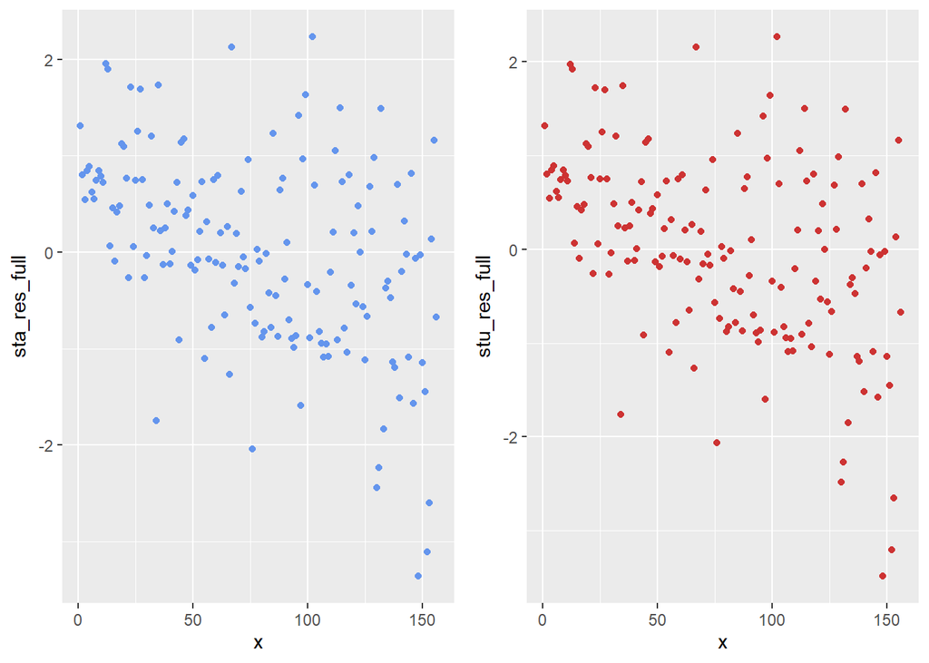

```r
sta_plot <- ggplot() + geom_point(data = dfstares_full, aes(x = x, y = sta_res_full), color = "cornflowerblue")

stu_plot <- ggplot()+geom_point(data = dfstures_full, aes(x = x, y = stu_res_full), color = "brown3")

ggarrange(sta_plot, stu_plot, ncol = 2, nrow = 1)
```

### **Variable Selection**

#### Model 2, 3, 4, 5

##### Adj R-squared

```r
# better to perform summary to check which is the most significant

MLR_2 <- lm(Score
                 ~ GDP
                 + SS
                 + HLE
                 + FTMLC
                 + Europe
                 + Gen,
                 data = data_2019)
MLR_3 <- lm(Score
                 ~ GDP
                 + SS
                 + HLE
                 + FTMLC
                 + Europe,
                 data = data_2019)
MLR_4 <- lm(Score
                 ~ GDP
                 + SS
                 + HLE
                 + FTMLC,
                 data = data_2019)
MLR_5 <- lm(Score
                 ~ GDP
                 + SS
                 + HLE,
                 data = data_2019)


RF <- round(summary(full_model)$adj.r.squared, 4)
R2 <- round(summary(MLR_2)$adj.r.squared, 4)
R3 <- round(summary(MLR_3)$adj.r.squared, 4)
R4 <- round(summary(MLR_4)$adj.r.squared, 4)
R5 <- round(summary(MLR_5)$adj.r.squared, 4)

adj_r_squared_table <- data.frame(
  Model = c("Full Model", "Model 2", "Model 3", "Model 4", "Model 5"),
  Adj_R_Squared = c(RF, R2, R3, R4, R5)
)

adj_r_squared_table %>%
  regulartable() %>%
  bold(part = "header") %>%
  autofit()
```

| Model | Adj_R_Squared |
| --- | --- |
| Full Model | 0.7740 |
| Model 2 | 0.7713 |
| Model 3 | 0.7694 |
| Model 4 | 0.7649 |
| Model 5 | 0.7209 |

**Conclusion**:

The **Full Model** is the best in terms of Adjusted R-Squared, explaining the most variability in the dependent variable. **Model 2,** **Model 3** and **Model 4** are also strong alternatives with slightly lower fits. While **Model 5** is the weakest and less preferable based on the Adjusted R-Squared values.

##### Mallows’ Cp

```r
CpF <- ols_mallows_cp(full_model, full_model)
Cp2 <- ols_mallows_cp(MLR_2, full_model)
Cp3 <- ols_mallows_cp(MLR_3, full_model)
Cp4 <- ols_mallows_cp(MLR_4, full_model)
Cp5 <- ols_mallows_cp(MLR_5, full_model)

num_parameters <- lapply(list(full_model, MLR_2, MLR_3, MLR_4, MLR_5),
                         function(x) length(coefficients(x)))


MallowsCp_table <- data.frame(
  Model = c("Full Model", "Model 2", "Model 3", "Model 4", "Model 5"),
  p = unlist(num_parameters),
  Mallows_Cp = c(CpF,Cp2,Cp3,Cp4, Cp5)
)

MallowsCp_table %>%
  regulartable() %>%
  bold(part = "header") %>%
  width(j = 1, width = 1) %>%
  width(j = 2, width = 0.7) %>%
  width(j = 3, width = 1.5)
```

| Model | p | Mallows_Cp |
| --- | --- | --- |
| Full Model | 8 | 8.000000 |
| Model 2 | 7 | 8.780767 |
| Model 3 | 6 | 9.081804 |
| Model 4 | 5 | 11.137711 |
| Model 5 | 4 | 39.737813 |

##### Model selection based on AIC

```r
models <- list(MLR_2, MLR_3, MLR_4, MLR_5)
mod.names <- c("MLR_2", "MLR_3", "MLR_4", "MLR_5")


aictab(cand.set = models, modnames = mod.names) %>%
  mutate(Delta_AICc = round(Delta_AICc, 7),
         ModelLik = round(ModelLik, 7),
         AICcWt = round(AICcWt, 7),
         Cum.Wt = round(Cum.Wt, 7)) %>%
  regulartable() %>%
  fontsize(part = "header", size = 10) %>%
  fontsize(size = 10) %>%
  bold(part = "header") %>%
  autofit()
```

| Modnames | K | AICc | Delta_AICc | ModelLik | AICcWt | LL | Cum.Wt |
| --- | --- | --- | --- | --- | --- | --- | --- |
| MLR_2 | 8 | 255.7760 | 0.0000000 | 1.0000000 | 0.4356289 | -119.3982 | 0.4356289 |
| MLR_3 | 7 | 255.9159 | 0.1398686 | 0.9324551 | 0.4062044 | -120.5796 | 0.8418334 |
| MLR_4 | 6 | 257.8023 | 2.0262889 | 0.3630755 | 0.1581662 | -122.6193 | 0.9999996 |
| MLR_5 | 5 | 283.3946 | 27.6186454 | 0.0000010 | 0.0000004 | -136.4973 | 1.0000000 |

- **MLR_2** is the best model, followed closely by **MLR_3**.
- **MLR_4** has moderate support but is not as strong as MLR_2 and MLR_3.
- **MLR_5** is the weakest model with the least support.

##### Best Subset Selection using BIC

```r
subset_model <- regsubsets(
  Score ~ GDP
  + Europe
  + SS
  + HLE
  + FTMLC
  + Gen
  + POC,
  data = data_2019,
  nbest = 2,  # min 2 x variables
  nvmax = 7) # max 7 x variables
summary(subset_model)
```

```
## Subset selection object
## Call: regsubsets.formula(Score ~ GDP + Europe + SS + HLE + FTMLC +
##     Gen + POC, data = data_2019, nbest = 2, nvmax = 7)
## 7 Variables  (and intercept)
##        Forced in Forced out
## GDP        FALSE      FALSE
## Europe     FALSE      FALSE
## SS         FALSE      FALSE
## HLE        FALSE      FALSE
## FTMLC      FALSE      FALSE
## Gen        FALSE      FALSE
## POC        FALSE      FALSE
## 2 subsets of each size up to 7
## Selection Algorithm: exhaustive
##          GDP Europe SS  HLE FTMLC Gen POC
## 1  ( 1 ) "*" " "    " " " " " "   " " " "
## 1  ( 2 ) " " " "    " " "*" " "   " " " "
## 2  ( 1 ) "*" " "    " " " " "*"   " " " "
## 2  ( 2 ) " " " "    "*" "*" " "   " " " "
## 3  ( 1 ) "*" " "    "*" " " "*"   " " " "
## 3  ( 2 ) " " " "    "*" "*" "*"   " " " "
## 4  ( 1 ) "*" " "    "*" "*" "*"   " " " "
## 4  ( 2 ) "*" "*"    "*" " " "*"   " " " "
## 5  ( 1 ) "*" " "    "*" "*" "*"   " " "*"
## 5  ( 2 ) "*" "*"    "*" "*" "*"   " " " "
## 6  ( 1 ) "*" "*"    "*" "*" "*"   " " "*"
## 6  ( 2 ) "*" "*"    "*" "*" "*"   "*" " "
## 7  ( 1 ) "*" "*"    "*" "*" "*"   "*" "*"
```

###### Plot

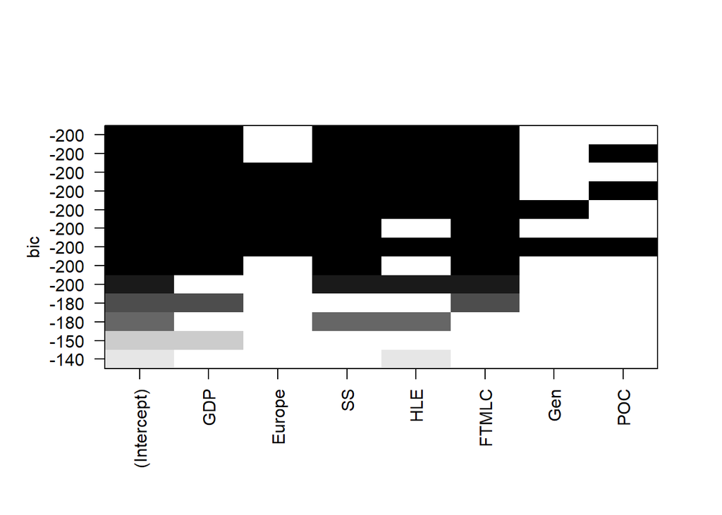

```r
plot(subset_model)
```

- The plot suggests that the best models (with the lowest BIC) include the intercept, GDP, SS, HLE, and FTMLC.
- Other variables like HLE and Europe have a moderate impact, whereas Gen and POC might not be as crucial for the best-fitting models.

#### Stepwise

##### Null Model

```r
nullmodel <- glm(Score ~ 1, data = data_2019)
summary(nullmodel)
```

```
##
## Call:
## glm(formula = Score ~ 1, data = data_2019)
##
## Coefficients:
##             Estimate Std. Error t value Pr(>|t|)
## (Intercept)  5.40710    0.08912   60.67   <2e-16 ***
## ---
## Signif. codes:  0 '***' 0.001 '**' 0.01 '*' 0.05 '.' 0.1 ' ' 1
##
## (Dispersion parameter for gaussian family taken to be 1.239036)
##
##     Null deviance: 192.05  on 155  degrees of freedom
## Residual deviance: 192.05  on 155  degrees of freedom
## AIC: 479.14
##
## Number of Fisher Scoring iterations: 2
```

The null model, which includes only an intercept parameter, has an Akaike Information Criterion (AIC) value of 479.14. This serves as a baseline for assessing other models.

##### Full Model

```r
fullmodel <- glm(Score ~ GDP
                 + Europe
                 + SS
                 + HLE
                 + FTMLC
                 + Gen
                 + POC,
                 data = data_2019)
summary(fullmodel)
```

```
##
## Call:
## glm(formula = Score ~ GDP + Europe + SS + HLE + FTMLC + Gen +
##     POC, data = data_2019)
##
## Coefficients:
##             Estimate Std. Error t value Pr(>|t|)
## (Intercept)   1.8805     0.2142   8.777 3.77e-15 ***
## GDP           0.7405     0.2172   3.409  0.00084 ***
## Europe        0.2172     0.1162   1.868  0.06368 .
## SS            1.0537     0.2380   4.428 1.83e-05 ***
## HLE           0.9673     0.3370   2.870  0.00471 **
## FTMLC         1.6152     0.3820   4.228 4.11e-05 ***
## Gen           0.4967     0.4936   1.006  0.31601
## POC           0.8993     0.5393   1.668  0.09752 .
## ---
## Signif. codes:  0 '***' 0.001 '**' 0.01 '*' 0.05 '.' 0.1 ' ' 1
##
## (Dispersion parameter for gaussian family taken to be 0.2799619)
##
##     Null deviance: 192.051  on 155  degrees of freedom
## Residual deviance:  41.434  on 148  degrees of freedom
## AIC: 253.89
##
## Number of Fisher Scoring iterations: 2
```

The full model, which includes all variables, has a lower AIC value of 253.89. This suggests that including all variables improves the model’s ability to explain the variation in the score and fit the data better than the null model.

- Despite the full model’s better performance compared to the null model, it’s important to consider the contribution of each variable. A simpler model with fewer predictors might achieve a similar fit. Therefore, subset selection techniques such as stepwise selection, forward selection, and backward elimination are being used to identify the most useful predictors.

##### Stepwise regression

```r
model.step <- step(nullmodel, scope =list(lower = nullmodel,
                                          upper = fullmodel,
                                          direction = "both"))
```

```
## Start:  AIC=479.14
## Score ~ 1
##
##          Df Deviance    AIC
## + GDP     1   71.011 325.93
## + HLE     1   75.242 334.96
## + SS      1   76.087 336.70
## + FTMLC   1  130.365 420.70
## + Europe  1  151.745 444.39
## + POC     1  163.493 456.03
## <none>       192.051 479.14
## + Gen     1  190.946 480.24
##
## Step:  AIC=325.93
## Score ~ GDP
##
##          Df Deviance    AIC
## + FTMLC   1   55.166 288.54
## + SS      1   56.903 293.38
## + HLE     1   62.361 307.67
## + POC     1   66.372 317.39
## + Gen     1   67.273 319.50
## + Europe  1   69.515 324.61
## <none>        71.011 325.93
## - GDP     1  192.051 479.14
##
## Step:  AIC=288.54
## Score ~ GDP + FTMLC
##
##          Df Deviance    AIC
## + SS      1   47.329 266.64
## + HLE     1   49.457 273.50
## + Europe  1   51.638 280.24
## <none>        55.166 288.54
## + POC     1   54.621 289.00
## + Gen     1   54.709 289.25
## - FTMLC   1   71.011 325.93
## - GDP     1  130.365 420.70
##
## Step:  AIC=266.64
```

[output cut: 35 more lines]

```
## - FTMLC   1   47.671 269.76
## - SS      1   49.032 274.16
##
## Step:  AIC=252.96
## Score ~ GDP + FTMLC + SS + HLE + POC + Europe
##
##          Df Deviance    AIC
## <none>        41.718 252.96
## + Gen     1   41.434 253.89
## - Europe  1   42.687 254.54
## - POC     1   42.857 255.16
## - HLE     1   44.055 259.46
## - GDP     1   44.770 261.97
## - SS      1   47.149 270.05
## - FTMLC   1   47.476 271.13
```

```r
# last one is the best model

summary(model.step)
```

```
##
## Call:
## glm(formula = Score ~ GDP + FTMLC + SS + HLE + POC + Europe,
##     data = data_2019)
##
## Coefficients:
##             Estimate Std. Error t value Pr(>|t|)
## (Intercept)   1.9548     0.2011   9.720  < 2e-16 ***
## GDP           0.7104     0.2152   3.302  0.00120 **
## FTMLC         1.6949     0.3737   4.535 1.18e-05 ***
## SS            1.0478     0.2379   4.404 2.01e-05 ***
## HLE           0.9737     0.3370   2.889  0.00444 **
## POC           1.0469     0.5190   2.017  0.04547 *
## Europe        0.2163     0.1162   1.861  0.06473 .
## ---
## Signif. codes:  0 '***' 0.001 '**' 0.01 '*' 0.05 '.' 0.1 ' ' 1
##
## (Dispersion parameter for gaussian family taken to be 0.2799849)
##
##     Null deviance: 192.051  on 155  degrees of freedom
## Residual deviance:  41.718  on 149  degrees of freedom
## AIC: 252.96
##
## Number of Fisher Scoring iterations: 2
```

- A stepwise regression method was performed, which involves adding and removing predictors to find the best model.
- The model with the lowest AIC value (252.96) includes the variables GDP per Capita, Freedom of making life choices, Social Support, Healthy Life Expectancy, Perception of Corruption, and European Region.
- The Generosity variable is excluded from the model, and the AIC value of this model is slightly lower than that of the full model, with a difference of 0.93, suggesting that Generosity does not contribute significantly to the explanatory power of the model.

##### Forward stepwise regression

```r
forward.model <- step(nullmodel,
                      scope = list(lower = nullmodel,
                                   upper = fullmodel,
                                   direction = "forward"))
```

```
## Start:  AIC=479.14
## Score ~ 1
##
##          Df Deviance    AIC
## + GDP     1   71.011 325.93
## + HLE     1   75.242 334.96
## + SS      1   76.087 336.70
## + FTMLC   1  130.365 420.70
## + Europe  1  151.745 444.39
## + POC     1  163.493 456.03
## <none>       192.051 479.14
## + Gen     1  190.946 480.24
##
## Step:  AIC=325.93
## Score ~ GDP
##
##          Df Deviance    AIC
## + FTMLC   1   55.166 288.54
## + SS      1   56.903 293.38
## + HLE     1   62.361 307.67
## + POC     1   66.372 317.39
## + Gen     1   67.273 319.50
## + Europe  1   69.515 324.61
## <none>        71.011 325.93
## - GDP     1  192.051 479.14
##
## Step:  AIC=288.54
## Score ~ GDP + FTMLC
##
##          Df Deviance    AIC
## + SS      1   47.329 266.64
## + HLE     1   49.457 273.50
## + Europe  1   51.638 280.24
## <none>        55.166 288.54
## + POC     1   54.621 289.00
## + Gen     1   54.709 289.25
## - FTMLC   1   71.011 325.93
## - GDP     1  130.365 420.70
##
## Step:  AIC=266.64
```

[output cut: 35 more lines]

```
## - FTMLC   1   47.671 269.76
## - SS      1   49.032 274.16
##
## Step:  AIC=252.96
## Score ~ GDP + FTMLC + SS + HLE + POC + Europe
##
##          Df Deviance    AIC
## <none>        41.718 252.96
## + Gen     1   41.434 253.89
## - Europe  1   42.687 254.54
## - POC     1   42.857 255.16
## - HLE     1   44.055 259.46
## - GDP     1   44.770 261.97
## - SS      1   47.149 270.05
## - FTMLC   1   47.476 271.13
```

```r
summary(forward.model)
```

```
##
## Call:
## glm(formula = Score ~ GDP + FTMLC + SS + HLE + POC + Europe,
##     data = data_2019)
##
## Coefficients:
##             Estimate Std. Error t value Pr(>|t|)
## (Intercept)   1.9548     0.2011   9.720  < 2e-16 ***
## GDP           0.7104     0.2152   3.302  0.00120 **
## FTMLC         1.6949     0.3737   4.535 1.18e-05 ***
## SS            1.0478     0.2379   4.404 2.01e-05 ***
## HLE           0.9737     0.3370   2.889  0.00444 **
## POC           1.0469     0.5190   2.017  0.04547 *
## Europe        0.2163     0.1162   1.861  0.06473 .
## ---
## Signif. codes:  0 '***' 0.001 '**' 0.01 '*' 0.05 '.' 0.1 ' ' 1
##
## (Dispersion parameter for gaussian family taken to be 0.2799849)
##
##     Null deviance: 192.051  on 155  degrees of freedom
## Residual deviance:  41.718  on 149  degrees of freedom
## AIC: 252.96
##
## Number of Fisher Scoring iterations: 2
```